# Family Firms Amidst the Global Financial Crisis: A Territorial Embeddedness Perspective on Downsizing

Converted from PDF `Amato-FamilyFirmsCrisisDownsizing-2023-JBE.pdf` · 24 pages · anchors: page `#pN`, block `#pN-bK`

Page 1

### Vol.:(0123456789) 1 3

Journal of Business Ethics (2023) 183:213–236 https://doi.org/10.1007/s10551-021-04930-0

### **Family Firms Amidst the Global Financial Crisis: A Territorial Embeddedness Perspective on Downsizing**

#### **Stefano Amato<sup>1</sup> · Alessia Patuelli<sup>1</sup> · Rodrigo Basco<sup>2</sup> · Nicola Lattanzi<sup>1</sup>**

Received: 18 August 2020 / Accepted: 23 August 2021 / Published online: 8 September 2021 © The Author(s) 2021

**Abstract** This study explores the downsizing propensity of family and non-family firms by considering their territorial embeddedness during both periods of economic stability and financial crisis. By drawing on a panel dataset of Spanish manufacturing firms for the period 2002–2015, we show that, all things being equal, family firms have a lower propensity to downsizing than non-family firms. When considering the effect of territorial embeddedness, we found that territorially embedded family firms have an even lower propensity to downsizing than their non-family counterparts. Furthermore, the concern of territorially embedded family firms for their employees’ welfare was particularly pronounced during the years of the global financial crisis. This result is explained by the existence of socially proximate relationships with the firms’ immediate surroundings, based on similarity and a sense of belonging, which push deeply rooted family firms to treat their employees as salient stakeholders during hard times. Overall, our study stresses the importance of local roots in moderating the relationship between family firms and downsizing.

**Keywords** Family firm · Downsizing · Territorial embeddedness · Locality · Global financial crisis · Manufacturing · Spain

#### **Introduction**

*How and to what extent do firms resort to downsizing when an economic downturn occurs?* This question becomes relevant because of the ethical aspects of firms’ downsizing choices in response to adverse external contingencies (Neto & Mullet, 2018). Grounded in agency theory and stakeholder theory (Carver, 2004), the decision to downsize is driven by conflicting moral and legal obligations towards shareholders and stakeholders (Hopkins & Hopkins, 1999).

Thus, the ethical dilemma of downsizing may emerge as a trade-off between preserving psychological and social contracts that bind employers, workers and local communities together (Van Buren, 2000) and owners’ financial goals and long-term firm sustainability (Hopkins & Hopkins, 1999). As an example, public opinion, in Spain, highlighted that many family firms survived the 2008 global financial crisis despite sacrificing profitability to save jobs (Arrondo-García et al., 2016). In this sense, the research stream focusing on the family nature of ownership and management has shown that family firms rely less on downsizing than non-family firms (e.g. Bassanini et al., 2013; Sanchez‐Bueno et al., 2019; Stavrou et al., 2007) because of stronger non-financial motives, such as moral obligations (Bjuggren, 2015), reputation (Block, 2010) and long-term orientation (Kappes & Schmid, 2013).

Whilst organizational identity arguments have been largely put forward to explain family firms’ greater concern for their employees’ welfare (Block, 2010; Stavrou et al., 2007), current evidence on family firms and downsizing is essentially “place-less” (Shrivastava & Kennelly, 2013). Specifically, most of existing research (with a few exceptions, see Kim et al., 2019) has overlooked territorial “anchorage” (i.e. embeddedness) where both family and

* Stefano Amato stefano.amato@imtlucca.it

Alessia Patuelli alessia.patuelli@imtlucca.it

Rodrigo Basco bascorodrigo@gmail.com

Nicola Lattanzi nicola.lattanzi@imtlucca.it

1 IMT School for Advanced Studies Lucca, Piazza S. Francesco, 19, 55100 Lucca, Italy

2 Sheikh Saoud bin Khalid bin Khalid Al‑Qassimi Chair in Family Business, American University of Sharjah, University City, 26666 Sharjah, United Arab Emirates

1 3

non-family firms are located as a contingent dimension to the decision to downsize. For instance, while family firms were found to provide greater employment stability during the latest global financial crisis (Ellul et al., 2018), evidence for this has been detached from any locational influence besides firm-specific characteristics, which is rather surprising given that firms do not exist in a vacuum devoid of connections with a place (Oinas, 1997).

To address the aforementioned research limitation, we link arguments from the organizational identity theory with the embeddedness perspective—which maintains that individual behaviours and choices are subject to social influences emerging from a flow of interactions and shifting relationships with others (Granovetter, 1985, 2005)—to hypothesize that the relationship between family firms and the propensity to downsize is contingent on the level of the firm’s territorial embeddedness. It is defined as the firm’s ties to a particular place and the degree to which it is conditioned by the economic and social dynamics occurring in the local *milieu* (Kalantaridis & Bika, 2006; Pallares-Barbera et al., 2004**)**. Following this reasoning and adding the temporal dimension of crisis, we argue that it is especially in times of adversity, such as the global financial crisis that the deeply rooted connections of family firms with their home territory are likely to materialize (Imperiale & Vanclay, 2016; Smith, 2016), thereby further enhancing their commitment to safeguarding employment.

Our findings indicate that, all other things being equal, family firms are 3 per cent less likely to downsize than their non-family counterparts. While territorial embeddedness per se does not affect the propensity to downsize, its combination with the family status of the firm provides a marker between the two types of firm. Indeed, territorially embedded family firms are found to be roughly 9% less likely of downsize than their territorially embedded non-family counterparts. However, while during the global financial crisis family and non-family firms were both forced to downsize, the former were 3 per cent less likely to do so. Finally, it is throughout the economic downturn that the influence of territorial embeddedness between the two types of firms was particularly evident. Specifically, we found that the

propensity to downsize of territorially embedded family firms was nearly 12 and half percentage points below that of embedded non-family firms during the global financial crisis.

This study makes both theoretical and practical contributions. First, it contributes to the family business literature by unveiling the spatial and temporal contingent conditions (Shrivastava & Kennelly, 2013) in which the implicit contracts between family firms and their employees are honoured (Van Buren, 2000). From this perspective, our empirical findings confirm recent evidence (e.g. Kim et al., 2019) on the conditioning effect of family firms’ local roots on the extent to which they resort to downsizing compared to non-family firms. Second, our study contributes to the ongoing debate regarding the territorial foundation of the firm’s downsizing choices and corporate social responsibility (Attig & Brockman, 2017; Lähdesmäki & Suutari, 2012). Nevertheless, our findings highlight the need to discriminate firms on the basis of their family status. In this sense, our article sheds new light on the so-called family firm-territory “nexus” (Amato et al., 2021a), interpreted as the existence of embedded ties between family firms and their immediate surroundings (i.e. locality) which have a profound effect on their attitudes towards their employees (Dekker & Hasso, 2016). Finally, this study has policy implications. The impact of the global financial crisis on the employment contraction has been highly asymmetric both across and within European countries, with some European regions and localities being more resilient than others (Giannakis & Bruggeman, 2017b). The findings allow us to speculate about the composition of the local business structure (i.e. prevalence of territorially embedded family firms) as the foundation of a region’s ability to withstand economic downturns (i.e. regional resilience). Hence, public policies should take into consideration the heterogeneity and ubiquity of economic actors (e.g. family firms) when tailoring policy interventions.

This article develops as follows. First, by providing an overview of the literature on downsizing and family firms, and disentangling the effects of territorial embeddedness and the global financial crisis, we present the theoretical background to our hypotheses. Then, we describe our sample, variables and econometric design. Finally, we discuss the results, concluding with remarks and suggestions for future research.

#### **Theoretical Background and Hypotheses**

#### **Downsizing and Family Firms**

Downsizing, understood as cutting jobs in the interests of firm’s efficiency (Cameron, 1994) and profitability in a

1 3

changing environment (Cascio, 1993; Datta et al., 2010), has received significant attention because of the ethical issues involved. On the one hand, particularly during hard times, moral and legal considerations towards shareholders oblige managers to secure the firm’s financial health and long-term sustainability. On the other hand, concerns for employees’ welfare prevail on managers to respect implicit and explicit contracts that tie employees to their firms (Hopkins & Hopkins, 1999). Hence, while downsizing is generally perceived as a violation of psychological and social contracts, which bind firms, individuals and their communities together (Coyle-Shapiro & Kessler, 2000), it may be considered fair as long as the decision is communicated to employees in a timely, appropriate and adequately motivated way (Hopkins & Hopkins, 1999). Notwithstanding that, the decision to downsize may also clash with the firm’s need to preserve corporate reputation (Love & Kraatz, 2009). That is because firms are generally prone to making choices consistent with prominent aspects of their identities (Ashforth & Mael, 1989). From this perspective, a shared set of values among members of an organization provides meaning and guides the behaviour of its constituents and enables the organization to locate itself in the social environment (Scott & Lane, 2000). Nevertheless, firms differ widely in their set of values and consequently in their behaviours.

Family firms, being a specific type of enterprise where family members are involved in running the business, are in a unique position to develop a distinctive organizational identity because family involvement can affect organizational goals (Basco, 2013) and, consequently, choices such as the decision to downsize (Stavrou et al., 2007). The existing research on family firms and employee-related outcomes (see Table 1) holds that family firms are less likely resort to lay-offs than non-family firms. This hypothesis and, in some cases, the empirical evidence is based on the organizational identity and social identity theory, along with complementary perspectives such as socio-emotional wealth, stakeholder theory and embeddedness.

On the one hand, kinship ties, a shared family name and common history, which are inextricably tied to the firm (Salvato & Melin, 2008), create a sense of belonging and togetherness between family members and the firm, which is generally viewed as an extension of the family itself (Deephouse & Jaskiewicz, 2013). Family values, such as trust, loyalty and mutual support, are usually embraced by non-family members (Zellweger et al., 2010). This, in turn, results in a congruence of values and goals between the family and non-family employees, enhancing motivation and cooperative behaviour (Kappes & Schmid, 2013), fair pay and working conditions (Bingham et al., 2011), trust and empathy (Zellweger et al., 2013), and tighter implicit contracts (Bassanini et al., 2013; Sraer & Thesmar, 2007). For instance, the specific organizational identity created by the family

involvement in the firm is reflected in higher employment growth (Diwisch et al., 2009), more employee-related investments (Kappes & Schmid, 2013) and a greater reluctance to cut wages (van Essen et al., 2015) and jobs (Sanchez‐Bueno et al., 2019; Stavrou et al., 2007) than non-family firms.

On the other hand, the values and principles shaping a family firm’s identity are not confined to the organizational boundaries, but extend outwards to relationships with external stakeholders, thus, becoming a “salient image of the firm in the eye of the public” (Zellweger et al., 2010, p. 58). Hence, heightened identification motivates family firms to engage in decisions that both enhance and preserve corporate reputation as an affective value of family members’ selfesteem (Naldi et al., 2013). This is especially true when a firm bears the family name (Deephouse & Jaskiewicz, 2013) and higher exposure of the family firm to the public eye can be a source of either affective benefit or harm for family members (Berrone et al., 2010).

Consequently, based on social identity arguments applied to the family business and the empirical evidence, we infer that family firms are more inclined to preserve implicit contracts with their employees (Bingham et al., 2011; Deephouse & Jaskiewicz, 2013) and avoid reputation–damaging decisions such as downsizing (Block, 2010). Thus, our baseline proposition is as follows:

P: The propensity to downsizing is lower for family firms than for non-family counterparts.

However, the aforementioned proposition is chiefly “place-less”, since it ignores the local ties between the firm and its home territory potentially influencing family firms’ caring attitudes towards their employees (Shrivastava & Kennelly, 2013). With few exceptions (e.g. Greenwood et al., 2010; Kim et al., 2019) current research has overlooked the socio-spatial conditions underlying downsizing decisions. Hence, to understand the differences in family and non-family firms’ downsizing propensity, we next focus on territorial embeddedness to disentangle how and when it conditions family firms’ downsizing propensity.

#### **Territorial Embeddedness, Family Firms and Downsizing**

Rejecting the “under-socialised” view represented by classical and neoclassical economics, the theory of embeddedness conceives economic action and decision-making as being subject to social influences stemming from a flow of repeated and accumulating interactions (Granovetter, 1985, 2005). Embeddedness has gained growing interest among geographers and regional scholars when investigating the interplay between the firm, the territory and the extent to which the firm depends on its context (Ratajczak-Mrozek, 2017). As a result, territorial embeddedness evolved as a

1 3

**Table 1** Empirical studies on family firm and employment outcomes

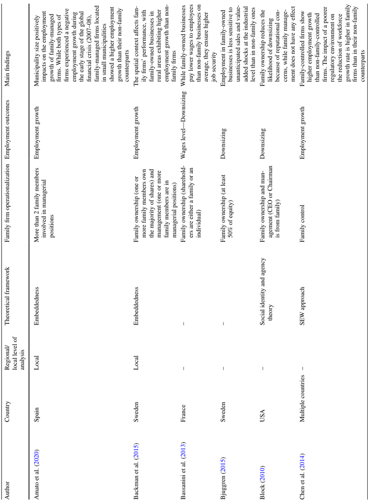

NOTE: complex table shown as an image of the PDF; the text below is a rough machine extraction and may be mis-aligned.

**extracted text (unreliable layout)**

Page 5

217 Family Firms Amidst the Global Financial Crisis: A Territorial Embeddedness Perspective on…

1 3

**Table 1** (continued)

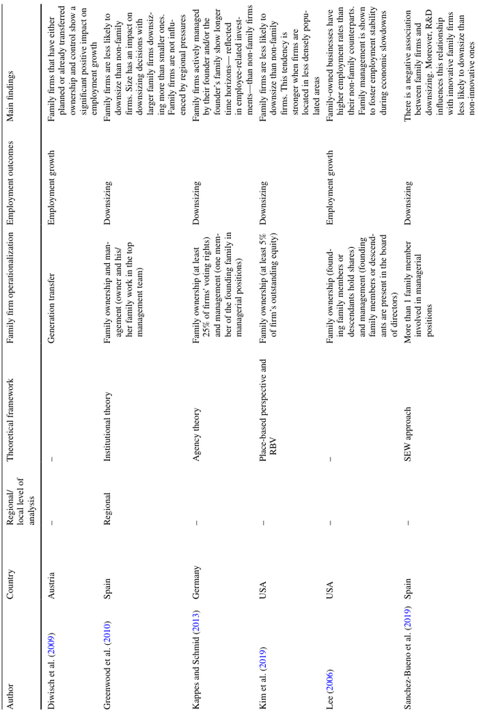

NOTE: complex table shown as an image of the PDF; the text below is a rough machine extraction and may be mis-aligned.

**extracted text (unreliable layout)**

Page 6

218 S. Amato et al.

1 3

**Table 1** (continued)

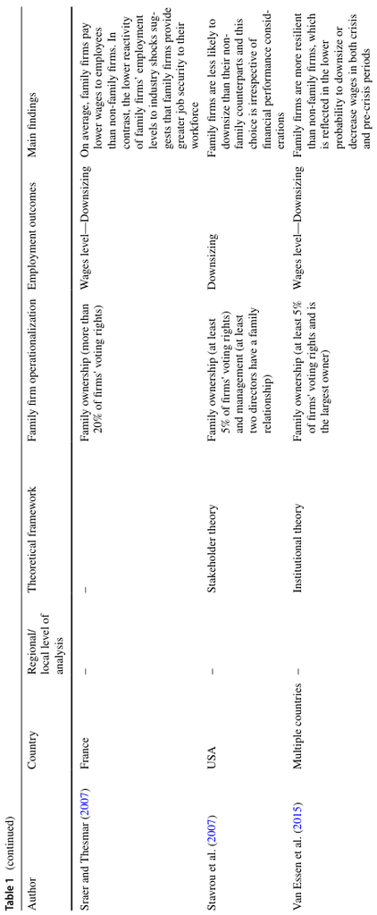

NOTE: complex table shown as an image of the PDF; the text below is a rough machine extraction and may be mis-aligned.

**extracted text (unreliable layout)**

Page 7

219 Family Firms Amidst the Global Financial Crisis: A Territorial Embeddedness Perspective on…

1 3

system interrelated with a given place (Dicken & Malmberg, 2001; Oinas, 1997) incorporating both the firm’s geographical location and the fabric of spatially bound relationships established therein (Filippi et al., 2011).

The concept of territorial embeddedness is based on the firm’s economic linkages with its locality. In this sense, the extent to which the firm’s transactions take place mainly in the immediate surroundings reflects its economic dependence on and the strength of the firm’s ties with the local *milieu* (Courtney et al., 2008; Kalantaridis & Bika, 2006)*.* As economic bonds intermingle with the social ones (Uzzi, 1999), enduring and spatially bounded economic activities evolve into a set of localized socially proximate relationships (Lähdesmäki et al., 2019). These relationships are based on a sense of similarity between local actors and on a common feeling of belonging to the same environment, where these connections take place (Jones & Woods, 2013; Pallares- Barbera et al., 2004).

Similarity is understood as the outcome of a spontaneous and cumulative process generated by history and repeated socio-economic actions occurring in a given place (Capello, 2019). Shared social and cultural values enable the reproduction of a local “consciousness” (Paasi, 2002) as a firm’s sense of being part of a given place that implicitly draws a boundary around a social community (Pallares-Barbera et al., 2004). Similarity creates a feeling of solidarity or “anchorage” to the local community, bringing together private and collective interests (Capello, 2019), and manifests itself either as informal rules or as tangible social actions towards the firm’s immediate surroundings (Paasi, 2002). The logics of similarity and belonging are found to mould the localized network of relationships (Filippi et al., 2011) in the form of reciprocal and trust-based ties binding the community together (Cox, 1998).

Therefore, repeated economic interactions are expected to lead to social relationships based on familiarity, emotional closeness and a sense of obligation (Huber, 2012). This, in turn, influences the firm’s consideration of the claims of stakeholders, in particular employees (Lähdesmäki et al., 2019) and its responsibility towards the surrounding community (Capello, 2019; Lähdesmäki & Suutari, 2012). As such, we expect that territorially embedded firms, based on their economic and social ties with the local environment, are less likely to downsize than non-embedded firms. Our first hypothesis is therefore:

H1: Territorially embedded firms exhibit a lower downsizing propensity than non-embedded firms.

However, some firm-specific characteristics may explain the varying strength of anchorage to the territory which may either amplify or diminish the underlying feelings of similarity and belonging. One of the firm-specific

characteristics is family status. Family firms are closely tied to the place where they operate (Bird & Wennberg, 2014), with these connections being not merely economic but also inherently social and affective (Amato et al., 2021a). For family members, the territory represents the place where they grew up, live together and where meaningful life experiences took place (Kalantaridis & Bika, 2006). The family history is inextricably tied to that of the firm, both sharing and concurrently influencing the same space of relationships (Smith, 2016). Hence, the overlapping of family and firm-related narratives contribute to strengthening the firm’s territorial roots.

Because of their long-lasting and pervasive action as both entrepreneurs and members of the community, family firms are in a unique position to contribute to and to be influenced by a shared set of social practices, values and traditions prevailing in a given locality (Soleimanof et al., 2018). These become institutionalized in the local setting and the basis for the emergence of an intense local consciousness (Paasi, 2002). However, the awareness of being part of the local community comes with raised social expectations towards the family firm along with monitoring and sanctioning mechanisms on its behaviour (Lähdesmäki & Suutari, 2012). Hence, family firms’ local roots turn into spatial loyalty that is a strong “sense of place” (Pallares-Barbera et al., 2004). It consists of an emotional connection stemming from family members’ attachment to and identity with a given area, which becomes “closely tied to organizational identity” (Shrivastava & Kennelly, 2013, p. 96) as reflected in their social behaviour (Pallares-Barbera et al., 2004) and in concrete social actions towards their community (Zellweger & Nason, 2008). For instance, previous empirical evidence shows that family firms are frequently involved in philanthropic initiatives (Lähdesmäki & Takala, 2012), local investments (Mitchell et al., 1997), and have stronger corporate social responsibility concerns towards the local community (Albers & Suwala, 2021). Downsizing choices are no exception.

Given the aforementioned arguments, when the economic linkages of family firms take place mainly at local level (Courtney et al., 2008; Kalantaridis & Bika, 2006), their feelings of similarity and belonging to their home territory are heightened, and consequently their awareness of their local responsibilities. Therefore, while we expect territorially embedded firms to be more reluctant to make redundancies than non-embedded firms, we maintain that the influence of territorial embeddedness is stronger for family firms than for their non-family counterparts. Hence, our second hypothesis is as follows:

H2: Territorial embeddedness influences the relationships between family firm status and downsizing propensity in such a way that the propensity to

1 3

downsize is lower for territorially embedded family firms than for territorially embedded non-family firms.

#### **Global Financial Crisis, Family Firms and Downsizing**

Social identity theory maintains that particular circumstances, such as economic downturns during which firms resort to downsizing (Datta & Basuil, 2015), can trigger a collective response in which individuals rediscover “social identities” (Stets & Burke, 2000). Whereas changed economic circumstances may provide a justification to cut jobs, social identification—which is conventionally associated with intra-group cohesion, altruism and empathy (Ashforth & Mael, 1989)—acts instead as a safeguard for employees. This can be particularly true for family firms, whereby uncertainty and the threat of looming unemployment brought on by an economic downturn may further heighten the family firm’s identification with the overall community (Smith, 2016).

Family cohesion is related to the emotional ties that bind relatives together and are necessary to build intragroup relationships and prevent fragmentation (Cabrera- Suárez et al., 2014). A common family identity based on a fundamental agreement about values, beliefs and ongoing interactions is a pre-requisite for such unity (Salvato & Melin, 2008). In adverse conditions we witness a reaction based on the inherent “ability of family members to rely on each other” (Sorenson, 2013, p. 127). Indeed, reciprocal support goes beyond the family domain to encompass those whose livelihood depends on the business (van Essen et al., 2015). This, in turn, strengthens intra-group cohesion and organizational identity. Over time, not only do non-family employees conform to the family values which become incorporated in the business (Sorenson, 2013), but they also become an extension of the owning family itself (Block, 2010). Conversely, massive downsizing may result in a significant loss of goodwill for family firms (Naldi et al., 2013), which might harm family harmony and corporate reputation (Deephouse & Jaskiewicz, 2013). Hence, empathic and altruistic behaviour may compel family firms to prioritize employees’ claims even in the face of declining profits.

In the light of the abovementioned arguments, we infer that an economic downturn, such as the global financial crisis, heightens the family firm identity, resulting in tighter long-term implicit contracts to employees. Therefore, our third hypothesis is as follows:

H3: During the global financial crisis the propensity to downsize is lower for family firms than nonfamily counterparts.

#### **Territorial Embeddedness, the Global Financial Crisis and Downsizing in Family Firms**

The impact of the global financial crisis has been highly asymmetric both across and within regions, with some regions and localities better able to withstand the social and economic repercussions (Giannakis & Bruggeman, 2017b). This imbalance has several reasons, including the peculiarities of highly embedded *milieu* such as found in rural areas, which show a greater ability to react to economic shocks than urban settings (Giannakis & Bruggeman, 2017a). In particular, whereas the social fabric of a given place (i.e. local social capital) is a key factor in regional and local development (Pike et al., 2016; Rutten & Boekema, 2007), the embeddedness of people and firms in territorial networks plays a crucial role in absorbing the impact of economic downturns (Cheshire et al., 2015).

Indeed, socially proximate relationships based on trust and reciprocity are deemed to emerge more vigorously in periods of crisis, as local actors share and mobilize their assets and resources to deal with the negative social and economic consequences (Imperiale & Vanclay, 2016). Local consciousness of being exposed to the same fate breeds solidarity and mutual assistance (Cheshire et al., 2015) and, hence, to a convergence of private and collective interests (Capello, 2019). Consequently, collective strategies enable those affected not only to cope with temporary adversity and distress, but also to reinforce their “sense of community, social cohesion, and social capital” (Imperiale & Vanclay, 2016, p. 216). Thus, both individuals and firms engage in pro-community initiatives involving the maintenance of employment levels.

This is particularly true for family firms whereby the social and emotional bonds with their home territory show their worth in times of crisis. For territorially embedded family firms, the welfare of employees as stakeholders becomes a matter of considerable importance (Lähdesmäki & Suutari, 2012). Indeed, even though worsening market conditions may justify lay-offs, the sense of belonging towards the territory (Capello, 2019) can deter embedded family firms from cutting jobs (Kim et al., 2019). Altruistic behaviour during difficult times enhances the legitimacy of both the family and the business in the eyes of the local community (Lähdesmäki & Takala, 2012). And, this legitimacy, upon which the survival and success of the firm largely depends, constrains the employer’s options as regards downsizing (Pallares-Barbera et al., 2004).

This constraint is primarily due to a mutual awareness of both family firms and non-family employees that they belong to the same territory, where social and economic relationships take place and are inextricably linked (Lähdesmäki et al., 2019). In particular, as adverse events such as the global financial crisis occur, profit motives yield to

1 3

an emotional closeness of the family towards non-family employees and the immediate surroundings whose wellbeing and prosperity would be threatened in the event of massive lay-offs (Kim et al., 2019). Thus, despite economic disadvantages, territorially embedded family firms may feel morally obliged to honour implicit contracts (Sraer & Thesmar, 2007; Svenn-Age, 1998) and to support the welfare of the local community (Pallares-Barbera et al., 2004), where both the firm and the family have been established for generations (Salvato & Melin, 2008).

Previous studies investigating the behaviour of family firms during economic downturns found a distinctive influence of the territory on their decisions to downsize. For instance, D’Aurizio and Romano (2013) show that during the global financial crisis, family firms worked harder to preserve employment levels than non-family firms when operating closer to their headquarters. These findings confirm that family firms’ intimate relationships with their home territory influence their decisions to cut jobs. More recently, Amato et al. (2020) found that, during the first years of the global financial crisis, family firms located in highly embedded contexts, such as small towns, resorted to making redundancies to a lesser extent than their non-family counterparts operating in the same area. Based on the abovementioned arguments, we can infer that the moderating effect of territorial embeddedness on the relationships between family employers and downsizing is further strengthened during the global financial crisis. Hence, our fourth hypothesis is as follows:

H4: The moderating effect of territorial embeddedness on the relationships between family firm status and downsizing is higher in crisis periods than in periods of economic stability.

Figure 1 depicts the proposed hypotheses.

#### **Data Sources and Variables**

#### **Sample and Data**

To test our hypotheses, we have relied on longitudinal microdata of a sample of Spanish manufacturing firms. Spain is an ideal setting for our study for several reasons. First, family firms are the backbone of the Spanish economy, accounting for nearly 90% of private firms and contributing to the nearly 67% of employment and 57% of Spain’s GDP<sup>1</sup> (IEF, 2017). Second, while family firms are quite widespread in all sectors, their incidence is particularly marked in the manufacturing sector accounting for 83% of the total (IEF, 2017). Third, Spain was among the European countries worst hit by the global financial crisis. After a period of sustained economic growth powered by the country’s integration in the European Union, since the second half of 2007 the Spanish economy started to collapse as a result of the combined adverse effect of the U.S. sub-prime financial crisis and the bursting of domestic real estate bubble (Jimeno & Santos, 2014). As a result, the GDP growth rate contracted sharply (from 3.5% in 2007 to − 5.4% in 2013) with staggering increases in both national debt (from 27% of GDP in 2008 to 80% in 2013) and unemployment (from 8.3 to 27% in 2013) (Royo, 2020). Labour market rigidity and the prevalence of temporary contracts exacerbated further job losses in Spain throughout the period 2007–2013 (Jimeno & Santos, 2014).

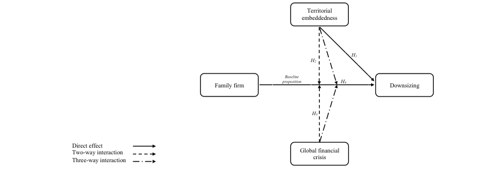

NOTE: figure/graphic rendered as an image from the PDF; its content is not machine-readable text. Caption (if any) follows as the next block.

**text found inside the figure**

Family firm Downsizing

Territorial embeddedness

*Baseline proposition*

Global financial

crisis

*H3*

*H1 H2*

Direct effect Two-way interaction Three-way interaction

*H4*

**Fig. 1** Hypothesis tested

1 The Instituto de la Empresa Familiar (IEF) is a non-profit organization owned by a hundred Spanish family firms leaders in their respective sectors. Since its foundation in 1992, IEF is the main representative of family firms in Spain. For more information about the IEF, please refer to: www.iefamiliar.com.

1 3

Table SD1 in the supplemental online data shows the sample distribution by industry and by region across the years. Panel A indicates that Fabricated metal products (2,763), Food & Tobacco (2,247) and Non-metal mineral products (1,532) have the highest number of observations. Panel B shows that observations are mostly concentrated in Cataluña (4,555), in Community of Madrid (3,021) and in Valencian Community (2,920).

#### **Variables and Measures**

#### **Dependent Variable**

Following the previous literature (Block, 2010; Cascio et al., 1997), we measure *Downsizing* as a dichotomous variable taking value “1” if the firm’s workforce decreased by more than 5% compared to the previous year, whereas positive or no changes are set at “0”. Hence, in the latter case, firms are regarded as “stable employers”.<sup>6</sup>

#### **Independent Variables**

**Family Firm** To identify family firms, we relied on the socalled “demographic approach” (Basco, 2013), which considers the involvement of family members in ownership, governance and managerial positions as a sufficient condition to capture the influence of the family on the business. For each surveyed firm, the ESEE provides information on the number of family members in managerial positions. Following previous studies (Greenwood et al., 2010; Sanchez‐ Bueno et al., 2019), we measure *Family firm* as a binary measure coded “1” if one or more members of the owning family work in the top management team of the focal firm and “0” otherwise.

**Territorial Embeddedness** Given the nature, depth and the extent of a firm’s ties to the local area (Greenberg et al., 2018; Kalantaridis & Bika, 2006), territorial embeddedness emerges as an elusive construct particularly for measurement purposes (Oinas, 1997; Ratajczak-Mrozek, 2017). Notwithstanding that, we follow Dekker and Hasso (2016) and Greenberg et al. (2018) who maintain that a firm’s anchorage to its territory is stronger the more the firm depends on its immediate surroundings for its sales, whereas a firm’s ties to its home base weaken as it expands further afield. Therefore, in accordance with Kalantaridis and Bika (2006), our measure mainly captures the market-oriented facet of

3 ESEE has paid attention at the attrition bias across years. This occurs wherever participants leave the study, resulting in systematic differences between the group that leaves and the one that continues the survey. For instance, if a firm answered the survey in 2002 and 2003 but refused to participate in 2004, this firm was surveyed again in 2005–2006. The response rate for the period 2002–2015 was equal to 91%.

4 NACE is the abbreviation for “Nomenclature statistique des activités économiques dans la Communauté européenne” and represents the European standard classification of productive economic activities. Particularly, ESEE adopts the NACE Rev. 2 classification implemented in 2006. For more information on NACE classification, please refer to: https://ec.europa.eu/eurostat/web/nace-rev2.

5 NUTS stands for “Nomenclature of Territorial Units for Statistics” and represents the level of territorial division for statistical purposes. The Spanish territory is divided in the following levels: NUTS 1 consists of seven groups of autonomous communities (*Agrupación de comunidades autónomas*); NUTS 2 comprises 19 autonomous communities and cities (*Comunidades y ciudades autónomas*); NUTS 3 is made up of 59 provinces and islands, (*Provincias, Islas*). However, the ESEE excludes the autonomous cities of Ceuta and Melilla, thus, leaving 17 autonomous communities. For more information on NUTS classification, please refer to: https://ec.europa.eu/eurostat/web/nuts/ background.

6 Since the number of employees consists of self-reported information, some might rightly argue the risk of social desirability bias, which occurs whenever survey respondents (e.g. individuals and firms) intentionally provide answers that they consider socially acceptable with the aim of gaining approval from others (Roxas & Lindsay, 2012). In our case, firms may enhance their social desirability as good employers or to avoid disapproval in the case of massive downsizing by misreporting the number of employees. However, the anonymity of surveyed firms of ESEE mitigates the risk of social desirability bias in our study. Indeed, as survey research shows (Krumpal, 2013; Roxas & Lindsay, 2012), the guarantee of anonymity and confidentiality is an effective way to promote full disclosure of sensitive or stigmatizing information compared to non-anonymous methods, thereby considerably reducing the risk of selection bias in survey research.

2 For more information about the SEPI Foundation and ESEE database, please refer to: www.fundacionsepi.es.

Page 11

223 Family Firms Amidst the Global Financial Crisis: A Territorial Embeddedness Perspective on…

1 3

territorial embeddedness. Specifically, each firm taking part in the survey is required to indicate the geographical area of its main market by choosing between six alternatives, namely: (i) local; (ii) provincial; (iii) regional; (iv) national; (v) abroad and (vi) domestic and abroad. In line with Dekker and Hasso (2016), we operationalize *Territorial embeddedness* as a dichotomous variable taking value “1”, if the local area is the main market for the company and “0” if it also operates in other markets.<sup>7</sup> We restrict the measure of embeddedness to the local level only because it delimits the closest administrative territory where both firms and people are situated and carry on their everyday working life (Paasi, 2002).<sup>8</sup> Additionally, and more importantly, local areas possess a so-called “imagined coherence” in the sense that their residents (e.g. individuals, families and firms) have a particular sense of identity tying them to the place, resulting in a perceived community with a shared pattern of behaviour (Jones & Woods, 2013).

**Global Financial Crisis** Even though the shock affected the whole period 2007–2015 with severe consequences in terms of job losses, the unemployment rate in Spain was uneven both across the economy as a whole and within the abovementioned period. Specifically, the average unemployment rate of manufacturing was generally below the unemployment rate in agriculture, construction and services. Based on the Economically Active Population Survey (EAPS),<sup>9</sup> the number of unemployed increased systematically during the period 2007–2012 within manufacturing. The slow recovery of the labour market started in 2013. Therefore, for the purpose of our study a dichotomous variable named *GFC* which takes value “1” for the years 2007–2012 and “0” otherwise is built accordingly.

#### **Control Variables**

To deal with unobserved heterogeneity, we control for a wide set of variables potentially affecting downsizing. We control for firms’ innovative activity as expressed by R&D expenditure to sales (*R&D intensity*) and innovation achievements in terms of both *Product* and *Process innovations* (dummy variable which takes value “1” if a firm introduced

product/process innovations, “0” otherwise) (Kappes & Schmid, 2013). As a firm’s international scope may affect the level of employment, we control for *Export intensity* as ratio of foreign sales to total revenues (Block, 2010). The variables *Age* (number of years since the firm was founded) and *Size* (logarithmic transformation of total assets) control for the effects related to the size and life cycle of the firm (Block, 2010; Sanchez‐Bueno et al., 2019). As downsizing is usually a consequence of a firm’s financial distress, we introduce *Financial constraints* as debt to total assets (Lins et al., 2013). To account for differences in performance, we control for *Profitability,* expressed as gross operating margin (Stavrou et al., 2007). The variables *Listed* (dichotomous variable which takes value “1” if the firm is publicly traded, “0” otherwise) and *Group* (dichotomous variable which takes value “1” if the firm is part of a corporate group, “0” otherwise) are introduced to account for constraints and requirements of employee-related policies and intra-group workers reallocation, respectively (Block, 2010). As businesses with high labour costs are more likely to downsize to reduce their overall expenditure, we control for *Labour cost ratio* computed as the ratio of labour costs over total sales (Sanchez‐Bueno et al., 2019). To account for investment in human capital, we control for *Employee T&D* measured by total expenses in training and development on labour costs (Baù et al., 2019).

Furthermore, as the reliance on temporary and part-time contracts may provide flexibility during demand fluctuations in terms of employment adjustment, we control for *Temporary workers ratio* (ratio of temporary workers over total workforce) and *Part-time workers ratio* (ratio of part-time workers over total workforce) (Muñoz-Bullón & Sánchez- Bueno, 2014). Since downsizing may result from the competitive pressure of rival firms (Gandolfi & Hansson, 2011), we control for the number of competitors in the main market of the company (*Competitors*). Rural areas are regarded as localities particularly rich in terms of social capital where family and community networks result in localization advantages for family firms (Backman & Palmberg, 2015). Hence, we control for *Rural* as binary variable which takes value “1” if the firm is located in towns or places with less than 50,000 inhabitants, “0” otherwise (OECD, 2012). Finally, a series of dummy variables are introduced to control for the industry, region and year associated with each observation.

#### **Empirical model**

To test the proposed hypotheses, we used panel data analysis with random effects specification. Since we have an unbalanced panel, we checked for the stationarity of our data using the Fisher unit-root test.<sup>10</sup> The null hypothesis is

7 Similarly to Dekker & Hasso (2016), Greenberg et al. (2018) adopt a market-oriented measure of embeddedness computed in terms of spatial proximity of the focal firm to more than 60% of customers.

8 With regard to the Spanish context, the local area overlaps with the local administrative unit (LAU) as identified by the European Union and consisting of 8,114 Municipalities (*Municipios*). LAU represents the lowest territorial units for statistical purposes.

9 The Economically Active Population Survey (EAPS) can be obtained from the National Statistics Institute website at the following link: https://www.ine.es/en.

10 Stata implements a range of tests for unit roots or stationarity in panel datasets with the general command “xtunitroot”. The Fisher

1 3

that all the panels contain a unit root, that is, all series are non-stationary. As we obtained *p* values lower than 0.05, we rejected the null hypothesis with all series consequently being stationary.

To investigate the decision to downsize with respect to the family status of the firm, the existence of territorially embedded ties and the global financial crisis, we estimate the following model:

where our dependent variable *Downsizing* represents the downsizing propensity; *α0* is the constant; *β1*, *β2* and *β3* represent the direct effect of our variables of interest on *Downsizing*; *Xi,t* is a matrix containing all two- and three-way interaction terms for our three main regressors; *γ* is the corresponding vector of coefficients; *Ci,t-1* is a matrix of additional control variables that captures firms’ heterogeneity potentially influencing downsizing choices, lagged by one year to lessen endogeneity from simultaneity bias (Block, 2010; Sanchez‐Bueno et al., 2019); *δ* is the vector related to coefficients; *Ti*, *Si* and *Ri* are time-specific, industry-specific and region-specific dummy effects, respectively; *τ*, *φ* and *ω* are the vectors corresponding to coefficients; and *εi,t* is the error term.

We estimate the above equation by using a linear probability model (LPM). LPM, a special case of OLS regression, is particularly suited to obtaining consistent and unbiased coefficients in the case of a dichotomous response variable (Wooldridge, 2010). One advantage of OLS over logistic models (e.g. Probit/Logit) is that it eases the interpretation of both the estimated coefficients, which directly represent the marginal effects and the interaction term which is rather problematic with logistic models due to the unclear signs or incorrect standard errors (Greene, 2010). Additionally, the marginal effect obtained from OLS model is very close to those obtained from non-linear models (Wooldridge, 2010). Finally, we deal with heteroscedasticity concerns by estimating robust standard errors.

While the sign and significance of the coefficients of the variables *Family firm* and *Territorial embeddedness* are related to the baseline proposition and Hypothesis 1, respectively, Hypotheses 2, 3, and 4 are operationalized by the following interaction terms: *Family*

*P*<sup>(</sup>*Downsizingi*,*t* = 1<sup>)</sup> = *훼*0 + *훽*1*Family firmi*,*t*

+ *훽*2*Territorial embeddednessi*,*t* + *훽*3*GFCt* + *훾Xi*,*t* + *훿Ci*, *t*−1 + *휏Ti* + *휑Si*,*t* + *휔Ri*,*t* + *휀i*,*t*

*firm*Territorial embeddedness*, *Family firm*GFC* and *Family firm*Territorial embeddedness*GFC.* For the sake of clarity, we interpret the interaction terms by group comparisons (Dinh et al., 2021). Given the existence of as many groups as possible combinations, a specific reference group is identified.<sup>11</sup> The sign and statistically significance of the marginal effect of a given group in comparison with the reference group provides straightforward evidence of differences across groups. Hence, to investigate the difference between family and non-family firm conditionally to territorial embeddedness, the global financial crisis and in both instances, the groups *Non-family firm*Territorial embeddedness*, *Non-family firm*GFC* and *Non-family firm*Territorial embeddedness*GFC* are compared with the reference groups *Family firm*Territorial embeddedness*, *Family firm*GFC* and *Family firm*Territorial embeddedness*GFC*, respectively. For the purpose of our study, while the choice of reference group leads to the same results, setting family firms as reference group also allows us to compare the same type of firms across different scenarios.

#### **Descriptive Statistics**

Footnote 10 (continued)

type has a null hypothesis that all panels contain a unit root and it is implemented by the command “xtunitroot fisher”.

11 In case of a dichotomous variable, Stata allows a change in the reference group with the command *b(1))i.* placed before the variable of interest. The lowest-numbered group (i.e. 0) is used as the reference group by default from the statistical package. The same applies both in case of single categorical variables and interaction terms.

Page 13

225 Family Firms Amidst the Global Financial Crisis: A Territorial Embeddedness Perspective on…

1 3

In Table 3, we report the correlation between our regression variables. While the association between family firm status and downsizing is positive but not statistically significant, territorial embeddedness is positively and significantly associated with downsizing. Both the global financial crisis and the labour cost ratio are closely related to downsizing. Inspection of the variance inflation factors (VIFs) displayed in the same table suggests that multicollinearity is not a concern in our data, as all VIF coefficients are below the tolerance threshold of 5 (Baù et al., 2019).

#### **Regression Results**

We report the results of our analysis in Table 4.<sup>13</sup> In Model 1 we introduce family firm variable along with control variables. The coefficient of *Family firm* is negative and statistically significant at the 0.1% level, suggesting that family firms—all things being equal—are more reluctant to downsize than non-family firms. Specifically, family firms are 3 per cent less likely to downsize than their non-family counterparts. By looking at the control variables, both process innovation (*Process innovation*) and R&D activities (*R&D intensity*) are negatively related to the propensity to downsize. Similarly, greater profitability (*Profitability*) and staff training (*Employee T&D*) are negatively linked to downsizing. While the size of the firm (*Size*) does not seem to have a significant impact on downsizing, greater levels of indebtedness (*Financial constraints*) do have a positive effect. As indicated by the coefficient of *Labour cost ratio*, a greater (relative) incidence of personnel costs is positively linked to downsizing. Likewise, we document a positive and negative coefficient of both *Temporary workers ratio* and *Part-time workers ratio,* which indicates that non-permanent employment contracts allow firms greater flexibility when deciding to lay-off.

In Model 2 we add the remaining two explanatory variables. The coefficient of *Territorial embeddedness* is positive but not statistically significant. Therefore, there is no evidence that the propensity to downsize is affected by the degree to which firms are anchored to their local area.

Therefore, Hypothesis 1 is not supported. Finally, the coefficient of *GFC* is strongly positive and statistically significant at the 0.1% level.<sup>14</sup> In particular, the propensity to engage in downsizing during the years of financial crisis is more than 13% higher than in periods of economic stability. In Model 3 we test Hypothesis 2 by comparing family and non-family firms at equal levels of territorial embeddedness. The marginal effect of the two-way interaction *Non-family firm***Territorial embeddedness*—as opposed to family firm counterparts as reference group—is positive and statistically significant at 1% level. This result suggests that, when it comes to downsizing, territorial embeddedness affects family and non-family firms in different ways, with territorially embedded family firms much being less likely to downsize. Specifically, for territorially embedded family firms the probability to downsize is 8.8% lower than their non-family and territorially embedded counterparts. Thus, Hypothesis 2 is supported. For a more straightforward interpretation of this result, we plot in Fig. 2a each pair of factors. It shows that the discrepancy—in terms of propensity to downsize—between family and non-family firms widens further when both types of firms are territorially embedded. Conversely, family firms themselves do not seem to differ on account of their embeddedness in the local *milieu* as shown by the marginal effect of the interaction *Family firm*Nonterritorial embeddedness* which, despite being positive, is not statistically significant.

In Model 4 we test Hypothesis 3 by comparing family and non-family firms during the global financial crisis. The marginal effect of the two-way interaction *Non-family firm***GFC*—as opposed to family firms as reference group— is positive and statistically significant at 1%, providing evidence that the two types of firms react differently as regards downsizing during the economic downturn. Particularly, family firms are found 3% less likely to downsize than their non-family counterparts. Additionally, Model 4 shows that the propensity to downsize of family firms was considerably higher (13.8%) during the global financial crisis than in periods of economic stability. Figure 2b depicts each pair of factors associated with the two-way interaction. Yet, even if the propensity to downsize increases for both types of firms during the global financial crisis, the downsizing propensity of family firms is always lower than that of non-family counterparts.

Finally, in Model 5 we test Hypothesis 4 by computing the marginal effect of the three-way interaction *Non-family firm***Territorial embeddedness***GFC* as opposed to family firms set as reference group. The marginal effect is positive

13 It is worth noting that lagging all control variables by one year – to mitigate endogeneity concerns – results in the loss of 1,392 firmyear observations. Hence, the sample used in the regression analysis consists of 20,251 firm-year observations distributed through 3,063 unique firms from 2002 to 2015.

14 Because of collinearity with GFC, in Models 2–5 the time dummies are not included in the estimations. Conversely, the variance inflation factor (VIF) of GFC would jump to 6.84, from to 1.02 in case of time dummies exclusion, hence leading to imprecise estimates of the coefficient values and omission of results. The estimation results with the inclusion of both GFC and time dummies can be found in the supplemental online data.

Footnote 14 (continued)

1 3

**Table 2** Descriptive statistics

Level of statistical significance <sup>+</sup>*p* < 0.10, **p* < 0.05, ***p* < 0.01, ****p* < 0.001

a The Wilcoxon rank-sum test determines whether two samples were selected from populations having the same distribution (Sample 1: Nonfamily firms; Sample 2: Family firms)

L Expressed in natural logarithm

W Winsor at 1 and 99% tail

Panel 2A: summary statistics for whole sample

[output not shown]

NOTE: table converted from PDF layout to HTML text; cell boundaries are reconstructed. See PDF if exact alignment matters.

Panel 2B: Difference of means and Wilcoxon rank-sum test

Page 15

227 Family Firms Amidst the Global Financial Crisis: A Territorial Embeddedness Perspective on…

1 3

**Table 3** Pearson correlation coefficients

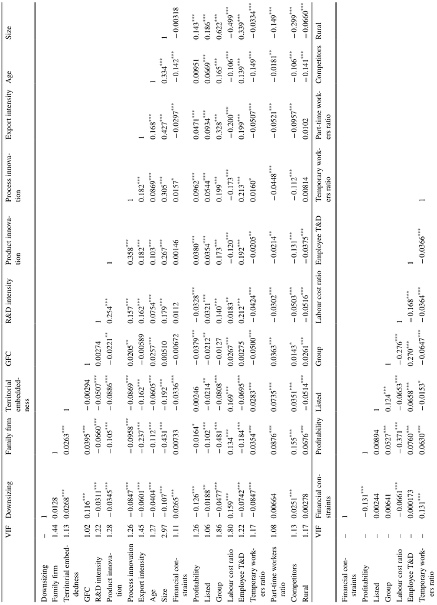

NOTE: complex table shown as an image of the PDF; the text below is a rough machine extraction and may be mis-aligned.

**extracted text (unreliable layout)**

Page 16

228 S. Amato et al.

1 3

#### **Robustness Check**

We performed several robustness tests to corroborate our results.<sup>15</sup> First, we performed a subsample analysis by restricting the observations to the territorial embeddedness, the years of global financial crisis and jointly to the territorial embeddedness and years of crisis, respectively. In all the aforementioned subsamples, the family firm coefficient is negative and highly significant. Second, in lieu of the dichotomic measure of family firms (i.e. *Family firm*), we employed a continuous measure counting the number of family members in managerial positions. Third, we used an alternative definition of downsizing by raising alternatively to 7 and 10% the percentage threshold of employment reduction as compared to the previous year. Fourth, given the importance of time for firms—regardless of type—to develop and nurture their attachment to the local *milieu* (Lähdesmäki et al., 2019; Smith, 2016), we omitted firm age from the estimates. Fifth, we used a matching procedure to improve the covariate balance between the treated (i.e. family firms) and the control groups (i.e. non-family firms) to enhance the estimation of the causal effect. In so doing, we implemented the coarsened exact matching procedure (CEM) algorithm (Iacus et al., 2012).<sup>16</sup> Finally, we used logistic regression models (Probit and Logit) to estimate our coefficients with the marginal effects of both Logit and Probit models that are very close to those obtained with LMP. In all the abovementioned cases, we obtained similar results to those reported in the main analysis, thus, confirming our findings.

Number of observations: 21,643*.* Mean VIF = 1.92

Level of statistical significance + *p* < 0.10, **p* < 0.05, ***p* < 0.01, ****p* < 0.001

**Table 3** (continued)

15 Supplemental online data provides the results of the robustness check (Table SD2).

16 In general terms, matching consists of pruning observations that have no close match on pretreatment covariates in both the treated and the control groups. We performed CEM algorithm with the command “cem” on Stata (Blackwell et al., 2009) and matched on four variables capturing the *age* of the firm, the number of *employees*, the *sales* and the *industry* to which firms belong.

**Table 4** Family firms, territorial embeddedness and downsizing

[output not shown]

NOTE: table converted from PDF layout to HTML text; cell boundaries are reconstructed. See PDF if exact alignment matters.

#### **Discussion**

Drawing on the perspectives of territorial embeddedness and organizational identity, this study investigates the downsizing propensity of family and non-family firms by considering the moderating effect of territorial embeddedness and the global financial crisis. Previous studies have shown that, when confronted with the ethical dilemma of preserving the firm’s financial health or occupational levels (Hopkins & Hopkins, 1999), family firms are less inclined to downsize compared with non-family firms (e.g. Bjuggren, 2015; Block, 2010; Sraer & Thesmar, 2007). However, the joint influence of territorial embeddedness—understood as the

embodiment of geographic and social proximity based on a sense of belonging and territorial identity (Lähdesmäki et al., 2019)—and external contingencies on downsizing choices has been largely overlooked. As firms “do not exist in a vacuum devoid of connection to actual locations” (Guthey et al., 2014, p. 259) and temporal context (Arrondo- García et al., 2016), anchorage to their home territory stands out both as a source of opportunities (Capello & Faggian, 2005; Uzzi, 1999) and constraints (Hess, 2004), with territorial embeddedness signalling a state of dependence on the place (Ratajczak-Mrozek, 2017). From this perspective, downsizing choices, both under normal circumstances and economic downturns, may be contingent on the set of economic, social and emotional connections that firms have established with their geographical and social *milieu* (Capello, 2019; Dicken & Malmberg, 2001).

The table presents linear probability model estimates based on a panel dataset over the period 2002–2015. The dependent variable is *Downsizing* which is coded “1” if the negative change in numbers of employees as compared to the previous year is higher than 5%. Positive changes are set to “0”. *Family firm* is a dummy variable equal to “1” if one or more family members occupy managerial position in the firm and “0” otherwise. *Territorial embeddedness* is a dummy variable equal to “1” if the local area represents the main market for the firm and “0” if the firm also operates in other markets (provincial, regional, national, abroad, domestic and abroad). *GFC* indicates years 2007–2012 during which the global financial crisis occurred. Robust clustered standard errors are reported in parentheses

Level of significance <sup>+</sup>*p* < 0.10, **p* < 0.05, ***p* < 0.01, ****p* < 0.001

**Table 4** (continued)

[output not shown]

NOTE: table converted from PDF layout to HTML text; cell boundaries are reconstructed. See PDF if exact alignment matters.

**Fig. 2 a** Margins plot family firm*territorial embeddedness. **b** Margins plot family firm*global financial crisis. **c** Margins plot family firm*territorial embeddedness*global financial crisis

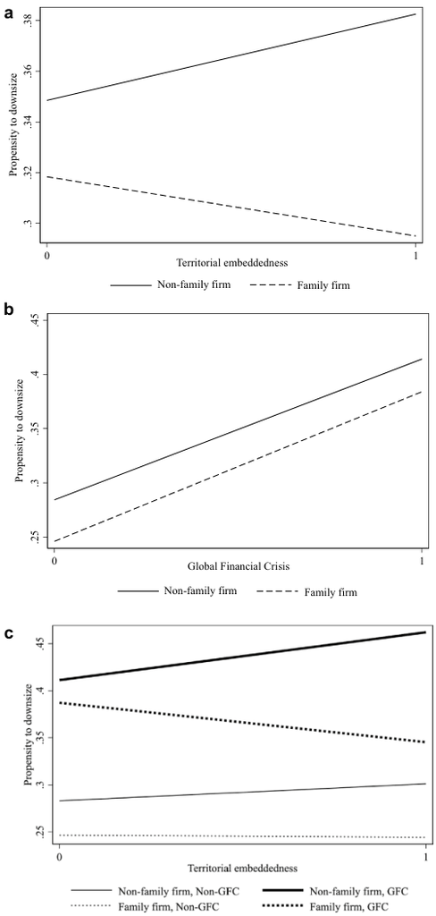

NOTE: figure/graphic rendered as an image from the PDF; its content is not machine-readable text. Caption (if any) follows as the next block.

**text found inside the figure**

.3 .32 .34 .36 .38 Propensity to downsize

0 1 Territorial embeddedness

Non-family firm Family firm

.25 .3 .35 .4 .45 Propensity to downsize

0 1 Global Financial Crisis

Non-family firm Family firm

**a**

**b**

**c**

Our results highlight the importance of territorial embeddedness for a greater understanding of the differences between family and non-family firms’ propensity to downsize, both in times of economic stability and subsequent downturns. Regarding the general stance towards downsizing, in line with previous studies (Bassanini et al., 2013; Stavrou et al., 2007), we corroborate that family firms have a lower propensity to downsizing than non-family firms. The family’s identification with the business and family values, such as closeness, reciprocity and trust, is likely to extend beyond the family domain, thereby heightening the psychological and social bonds between family firms and their employees (Bingham et al., 2011; Deephouse & Jaskiewicz, 2013). While territorial embeddedness per se does not affect downsizing propensity, in the case of family firms it was found to play an important role. Specifically, the strong economic links and territorial identity of family firms turn into a spatial loyalty which further mitigates the propensity to downsize compared to non-family firms. Hence, as local roots provide locational advantages to family firms (Backman & Palmberg, 2015; Baù et al., 2019), our findings support earlier studies showing the association between the embeddedness of family firms in the local *milieu* and their pro-social behaviour (Berrone et al., 2010; Dekker & Hasso, 2016). As the global financial crisis forced firms to cut jobs, our results reveal different responses, with family firms found to be less likely to downsize than non-family counterparts. This finding is at odds with that of Lins et al. (2013) who have shown that, during the early years of the global financial crisis (i.e. 2008–2009), family firms were equally likely to downsize as non-family firms. Conversely, this result is consistent with previous studies highlighting the altruistic behaviour of family firms towards their employees in the event of industry-specific shocks (Sraer & Thesmar, 2007) or economic downturns (Lee, 2006; van Essen et al., 2015). Specifically, our study confirms the findings of Arrondo- García et al. (2016) which reveal that during the most acute stages of the global financial crisis in Spain, family firms provided more employment stability than other firms.

However, considering separately the effects of territorial embeddedness and the global financial crisis on family versus non-family firms only offers a partial view of how the contextual dimensions influence firms’ downsizing choices. Indeed, when territorial embeddedness and the global financial crisis are considered simultaneously, we found that the concern of territorially embedded family firms for their employees particularly stands out in times of adversity. Socially proximate relationships with the firms’ immediate surroundings, based on similarity and affective bonds push family firms to consider the needs of their employees whose well-being and that of the local community would be endangered in the event of massive lay-offs. The difference

in the propensity to downsize between territorially embedded family and non-family firms equals nearly 12%, showing that family firms downsized less than non-family firms. This result reveals the amplified spatial loyalty of family firms in time of crisis, which does not appear to the same extent when territorial embeddedness and the global financial crisis are considered separately (8.8 and 3%, respectively). These findings are consistent with D’Aurizio and Romano (2013) and Amato et al. (2020), who have shown the role of location in the decision to safeguard the employment levels of family firms during the early years of the global financial crisis. Hence, our study confirms the uniqueness of territorially embedded family firms in limiting the detrimental effects of economic downturns on employment.

#### **Contributions and Policy Implications**

Our study has theoretical and practical implications. First, it contributes to the family business literature examining the downsizing propensity of family and non-family firms (Amato et al., 2021b) based on embeddedness in the home territory and external contingencies (the global financial crisis). In this sense, we attempt to address the place-less research gap in family business studies (Stough et al., 2015). Following the debate into the locational effect on the prosocial behaviour of family firms (Dekker & Hasso, 2016; Kim et al., 2019), we reveal the conditions under which the favourable attitudes of family firms towards their employees are likely to materialize. While previous studies considered the characteristics of the territory where the family firm is located (Greenwood et al., 2010; Kim et al, 2019), we show that the anchorage of family firms in their local *milieu* clearly affects their propensity to downsize. In this way, our results reveal that the intimate connections between family firms and their immediate surroundings—arising from a deeper sense of place and togetherness with their home territory (Kim et al., 2019)—result in heightened awareness of the needs of their employees, as salient stakeholders, in times of adversity (Van Buren, 2000).

Second, this research contributes to the ongoing debate on the pro-social behaviour of businesses—with respect to safeguarding employment—and localities (Attig & Brockman, 2017; Lähdesmäki et al., 2019). As firms’ local responsibilities are linked to geographical areas and socially proximate relationships, our study highlights the importance of distinguishing firms according to their type—that is between family and non-family firms—when the territorial foundations of corporate social responsibility are investigated. In particular, by introducing the spatial scope of embeddedness into the investigation of family firms’ downsizing choices (Hess, 2004; Ratajczak-Mrozek, 2017), we corroborate family firms as a distinctive type of enterprise (Shrivastava & Kennelly, 2013), deeply rooted in a given place (Amato et al., 2021a)

and committed to balancing survival and success with the well-being of the local community where they are placed (Berrone et al., 2010; Kurland & McCaffrey, 2020).

Finally, our research has implications for policy makers. As the negative repercussions of the global financial crisis spread across European regions in a markedly uneven manner (Groot et al., 2011), the concept of regional resilience, generally understood as the ability of a regional or local economy to withstand recessionary shocks, has attracted increasing interest (Fratesi & Perucca, 2018). In light of our findings, regional authorities should consider family firms’ embeddedness and concentration in their home territories when tailoring either swift responses to the impact of economic downturn or place-based policies aimed at rebalancing the territorial effects of economic crisis (e.g. European cohesion policy) (Giannakis & Bruggeman, 2017b). In addition to this, our research highlights the need for more awareness by policymakers of the unique and valuable role of family firms when policies aimed at fostering regional and local growth are designed (Basco & Bartkevičiūtė, 2016; Pike et al., 2016).

#### **Limitations and Avenues for Future Research**

Our research has several limitations which could pave the way for future research. First, our definition of family firm does not consider either ownership thresholds or the role of the controlling generation. As previous studies have shown, the consideration of non-economic aspects affecting downsizing are heavily dependent upon both the percentage of common stock owned by the founding family (Block, 2010) and the generation in control (Arrondo-García et al., 2016). Hence, future studies should investigate whether and to what extent territorial embeddedness influences downsizing propensity in different ways depending on the thresholds of family ownership and between the first generation vs. multigenerational family businesses.

Second, as our study relies entirely on a demographic approach to define family firms, future studies should test the consistency of our results with multiple definitions of family firms, integrating the components of involvement and essence approaches accounting for “soft” factors such as the vision and intentions (Basco, 2013).

Third, alternative measures of territorial embeddedness could be employed to investigate whether family firms’ downsizing propensity is sensitive to different operationalizations of local roots. Specifically, alternative and complementary measures—based on the distance from headquarters (Berrone et al., 2010; D’Aurizio & Romano, 2013), stakeholder proximity (Amato et al., 2021a), place tenure (Baù et al., 2019) and percentage of inputs and information coming from the local setting (Kalantaridis & Bika, 2006) among other factors. However, the most promising

way to face the challenge of measuring a firm’s local ties is to validate a “holistic” measure of territorial embeddedness entailing the multiple underlying dimensions, capable of fully grasping the conditioning effect of local *milieu* on a firm’s decision-making and outcomes.<sup>17</sup> Fourth, as our study considers only one country (Spain), future research should expand the analysis to other countries to account for the influence of different institutional and cultural settings on the decision to downsize in response to recessionary shocks (Lins et al., 2013). Since our research does not consider differences in regional labour markets, which could potentially limit a firm’s room for manoeuvre as regards downsizing (Svenn-Age, 1998), future research should investigate the sensitivity of territorially embedded family firms to differences in labour markets (Muñoz-Bullón & Sánchez-Bueno, 2014). Fifth, as our study develops from a micro-level approach, future studies may step into a meso-level perspective to explore the role of the collective aggregate actions (i.e. family firms “density”) as a source of regional resilience (Block & Spiegel, 2013). Sixth, in addition to economic downturns, other types of exogenous shocks such as natural disasters may adversely affect the economic and social structure of a given region or locality (Imperiale & Vanclay, 2016). Hence, it would be worth deepening the role of family firms’ spatial loyalty in coping with such adverse events (Cheshire et al., 2015; Smith, 2016). Finally, the family firm-territory “nexus” stands out as a promising opportunity for investigation with qualitative research methods (e.g. case studies, in-depth interviews). Indeed, a qualitative approach may prove extremely useful in developing new theories and testing existing ones. Only through an in-depth investigation of the economic and socio-spatial dynamics in context, might it be possible to understand the *genius loci* of family firms, that is, how the sense of place is produced and evolves across time (Shrivastava & Kennelly, 2013), uniquely influencing the relationships between family firms, territory and prosocial behaviour.

**Supplementary Information** The online version contains supplementary material available at https://doi.org/10.1007/s10551-021-04930-0.

**Acknowledgments** We are grateful to Lorenzo Dal Maso (Alma Mater Studiorum – University of Bologna), Armando Rungi and Francesco Serti (IMT School for Advanced Studies Lucca), and Francesco Ragiotto (University of Udine) for their valuable suggestions. We are also grateful to Section Editor Julia Roloff and to the three anonymous referees for their critical and constructive comments. As an early version of this work was presented during a research seminar held on the 22nd

17 We would like to thank one of the reviewers who suggested the opportunity for the validation on an all-encompassing construct of territorial embeddedness beyond the firm’s economic dependency, for its sales, to the locality.

of October 2018 at the Centre of Family Ownership and Enterprise (CeFEO) of Jönköping International Business School (Sweden), we would like to thank its director, Francesco Chirico, and his colleagues for their hospitality.

**Funding** Open access funding provided by Scuola IMT Alti Studi Lucca within the CRUI-CARE Agreement. This research did not receive any specific grant from funding agencies in the public, commercial, or not-for-profit sectors.

#### **Declarations**

**Conflict of interest** The authors declare that they have no known competing financial interests or personal relationships that could have appeared to influence the work reported in this paper.

**Open Access** This article is licensed under a Creative Commons Attribution 4.0 International License, which permits use, sharing, adaptation, distribution and reproduction in any medium or format, as long as you give appropriate credit to the original author(s) and the source, provide a link to the Creative Commons licence, and indicate if changes were made. The images or other third party material in this article are included in the article's Creative Commons licence, unless indicated otherwise in a credit line to the material. If material is not included in the article's Creative Commons licence and your intended use is not permitted by statutory regulation or exceeds the permitted use, you will need to obtain permission directly from the copyright holder. To view a copy of this licence, visit http://creativecommons.org/licenses/by/4.0/.

#### **References**

Albers, H.-H., & Suwala, L. (2021). Famiy firms and corporate spatial

responsabiliy in Germany: Implications for urban and regional planning and management. *Family business and regional development* (1st ed.). Routledge. Amato, S., Basco, R., Gomez-Anson, S., & Lattanzi, N. (2020). Fam-

ily-managed firms and employment growth during an economic downturn: Does their location matter? *Baltic Journal of Management, 15*(4), 607–630. Amato, S., Backman, M., & Peltonen, J. (2021a). Are family firms

more locally embedded? Findings from the Finnish context. *Family Business and Regional Development* (1st Ed.). Routledge. Amato, S., Basco, R., & Lattanzi, N. (2021b). Contextualizing employ-

ment outcomes in family business research: Current findings and future research avenues. *Management Review Quarterly*. https:// doi.org/10.1007/s11301-021-00226-9. Arrondo-García, R., Fernández-Méndez, C., & Menéndez-Requejo, S.

(2016). The growth and performance of family businesses during the global financial crisis: The role of the generation in control. *Journal of Family Business Strategy, 7*(4), 227–237. Ashforth, B. E., & Mael, F. (1989). Social identity theory and the

organization. *The Academy of Management Review, 14*(1), 20–39. Attig, N., & Brockman, P. (2017). The local roots of corporate social

responsibility. *Journal of Business Ethics, 142*, 496–497. Backman, M., & Palmberg, J. (2015). Contextualizing small family

firms: How does the urban–rural context affect firm employment growth? *Journal of Family Business Strategy, 6*(4), 247–258. Basco, R. (2013). The family’s effect on family firm performance: A

model testing the demographic and essence approaches. *Journal of Family Business Strategy, 4*(1), 42–66.

Basco, R., & Bartkevičiūtė, I. (2016). Is there any room for family busi-

ness into European union 2020 strategy? Family business and regional public policy. *Local Economy, 31*(6), 709–732. Bassanini, A., Breda, T., Caroli, E., & Rebérioux, A. (2013). Working

in family firms: Paid less but more secure? Evidence from French matched employer-employee data. *ILR Review, 66*(2), 433–466. Baù, M., Chirico, F., Pittino, D., Backman, M., & Klaesson, J. (2019).

Roots to grow: Family firms and local embeddedness in rural and urban contexts. *Entrepreneurship Theory and Practice, 43*(2), 360–385. Berrone, P., Cruz, C., Gomez-Mejia, L. R., & Larraza, M. (2010).

Socioemotional wealth and corporate responses to institutional pressures: Do family-controlled firms pollute less? *Administrative Science Quarterly, 55*(1), 82–113. Bingham, J. B., Gibb Dyer, W., Smith, I., & Adams, G. L. (2011).

A stakeholder identity orientation approach to corporate social performance in family firms. *Journal of Business Ethics, 99*(4), 565–585. Bird, M., & Wennberg, K. (2014). Regional influences on the preva-

lence of family versus non-family start-ups. *Journal of Business Venturing, 29*(3), 421–436. Bjuggren, C. M. (2015). Sensitivity to shocks and implicit employ-

ment protection in family firms. *Journal of Economic Behavior & Organization, 119*, 18–31. Blackwell, M., Iacus, S., King, G., & Porro, G. (2009). Cem: Coars-

ened exact matching in stata. *The Stata Journal, 9*(4), 524–546. Block, J. (2010). Family management, family ownership, and down-

sizing: Evidence from S&P 500 firms. *Family Business Review, 23*(2), 109–130. Block, J. H., & Spiegel, F. (2013). Family firm density and regional

innovation output: An exploratory analysis. *Journal of Family Business Strategy, 4*(4), 270–280. Cabrera-Suárez, M. K., de Déniz-Déniz, M. L. C., & Martín-Santana,

J. D. (2014). The setting of non-financial goals in the family firm: The influence of family climate and identification. *Journal of Family Business Strategy, 5*(3), 289–299. Cameron, K. S. (1994). Strategies for successful organizational down-

sizing. *Human Resource Management, 33*(2), 189–211. Capello, R. (2019). Interpreting and understanding territorial identity.

*Regional Science Policy & Practice, 11*(1), 141–158. Capello, R., & Faggian, A. (2005). Collective learning and relational

capital in local innovation processes. *Regional Studies, 39*(1), 75–87. Carballo-Cruz, F. (2011). Causes and consequences of the Spanish

economic crisis: Why the recovery is taken so long? *Panoeconomicus, 58*(3), 309–328. Carver, R. H. (2004). If the river stopped: A talmudic perspective on

downsizing. *Journal of Business Ethics, 50*(2), 137–147. Cascio, W. F., Young, C. E., & Morris, J. R. (1997). Financial conse-

quences of employment-change decisions in major U.S. corporations. *Academy of Management Journal, 90*(5), 1175–1189. Cascio, W. F. (1993). Downsizing: What do we know? What have we

learned? *Academy of Management Perspectives, 7*(1), 95–104. Chen, Q., Hou, W., Li, W., Wilson, C., & Wu, Z. (2014). Family con-

trol, regulatory environment, and the growth of entrepreneurial firms: International evidence. *Corporate Governance: An International Review, 22*(2), 132–144. Cheshire, L., Esparcia, J., & Shucksmith, M. (2015). Community resil-

ience, social capital and territorial governance. Ager. *Revista De Estudios Sobre Despoblación y Desarrollo Rural, 18*, 7–38. Courtney, P., Lépicier, D., & Schmitt, B. (2008). Spatial patterns of

production linkages in the context of Europe’s small towns: How are rural firms linked to the local economy? *Regional Studies, 42*(3), 355–374. Cox, K. R. (1998). Locality and community: Some conceptual issues.

*European Planning Studies, 6*(1), 17–30.

Coyle-Shapiro, J., & Kessler, I. (2000). Consequences of the psycho-

logical contract for the employment relationship: A large scale survey. *Journal of Management Studies, 37*(7), 903–930. D’Aurizio, L., & Romano, L. (2013). Family firms and the great Reces-

sion: Out of sight, out of mind? Temi di Discussione (working paper) n. 905, Banca d’Italia Datta, D. K., & Basuil, D. A. (2015). Does employee downsizing really

work?: The empirical evidence. In M. Andresen & C. Nowak (Eds.), *Human resource management practices* (pp. 197–221). Springer. Datta, D. K., Guthrie, J. P., Basuil, D., & Pandey, A. (2010). Causes

and effects of employee downsizing: A review and synthesis. *Journal of Management, 36*(1), 281–348. Deephouse, D. L., & Jaskiewicz, P. (2013). Do family firms have better

reputations than non-family firms? An integration of socioemotional wealth and social identity theories: Corporate reputation in family firms. *Journal of Management Studies, 50*(3), 337–360. Dekker, J., & Hasso, T. (2016). Environmental performance focus in

private family firms: The role of social embeddedness. *Journal of Business Ethics, 136*(2), 293–309. Dicken, P., & Malmberg, A. (2001). Firms in territories: A relational

perspective. *Economic Geography, 77*(4), 345–363. Dinh, T. Q., Calabrò, A., Campopiano, G., & Basco, R. (2021). The

Impact of politically connected CEOs and boards of directors on firm performance: A study of Vietnamese family and nonfamily firms. *Entrepreneurship Theory and Practice*. https://doi.org/10. 1177/1042258720985477 Diwisch, D. S., Voithofer, P., & Weiss, C. R. (2009). Succession and

firm growth: Results from a non-parametric matching approach. *Small Business Economics, 32*(1), 45–56. Ellul, A., Pagano, M., & Schivardi, F. (2018). Employment and wage

insurance within firms: Worldwide evidence. *The Review of Financial Studies, 31*(4), 1298–1340. Filippi, M., Frey, O., & Torre, A. (2011). The modalities of territorial

embeddedness of french cooperative groups. In A. Torre & J.-B. Traversac (Eds.), *Territorial governance* (pp. 43–63). Physica- Verlag HD. Fratesi, U., & Perucca, G. (2018). Territorial capital and the resilience

of European regions. *The Annals of Regional Science, 60*(2), 241–264. Gandolfi, F., & Hansson, M. (2011). Causes and consequences of

downsizing: Towards an integrative framework. *Journal of Management & Organization, 17*(4), 498–521. Giannakis, E., & Bruggeman, A. (2017a). Economic crisis and regional

resilience: Evidence from Greece: Economic crisis and regional resilience. *Papers in Regional Science, 96*(3), 451–476. Giannakis, E., & Bruggeman, A. (2017b). Determinants of regional

resilience to economic crisis: A European perspective. *European Planning Studies, 25*(8), 1394–1415. Granovetter, M. (1985). Economic action and social structure: The

problem of embeddedness. *American Journal of Sociology, 91*(3), 481–510. Granovetter, M. (2005). The impact of social structure on economic

outcomes. *Journal of Economic Perspectives, 19*(1), 33–50. Greenberg, Z., Farja, Y., & Gimmon, E. (2018). Embeddedness and

growth of small businesses in rural regions. *Journal of Rural Studies, 62*, 174–182. Greene, W. (2010). Testing hypotheses about interaction terms in non-

linear models. *Economics Letters, 107*(2), 291–296. Greenwood, R., Díaz, A. M., Li, S. X., & Lorente, J. C. (2010). The

multiplicity of institutional logics and the heterogeneity of organizational responses. *Organization Science, 21*(2), 521–539. Groot, S. P. T., Mohlmann, J. L., Garretsen, J. H., & de Groot, H. L. F.

(2011). The crisis sensitivity of European countries and regions: Stylized facts and spatial heterogeneity. *Cambridge Journal of Regions, Economy and Society, 4*(3), 437–456.

Guthey, G. T., Whiteman, G., & Elmes, M. (2014). Place and sense of

place: Implications for organizational studies of sustainability. *Journal of Management Inquiry, 23*(3), 254–265. Hess, M. (2004). ‘Spatial’ relationships? Towards a reconceptualiza-

tion of embeddedness. *Progress in Human Geography, 28*(2), 165–186. Hopkins, W. E., & Hopkins, S. A. (1999). The ethics of downsizing:

Perceptions of rights and responsibilities. *Journal of Business Ethics, 18*, 145–156. Huber, F. (2012). On the role and interrelationship of spatial, social

and cognitive proximity: Personal knowledge relationships of R&D workers in the Cambridge information technology cluster. *Regional Studies, 46*(9), 1169–1182. Iacus, S. M., King, G., & Porro, G. (2012). Causal inference without

balance checking: Coarsened exact matching. *Political Analysis, 20*(1), 1–24. IEF. (2017). *La dimensión empresarial como factor de competitividad*.

Instituto de la Empresa Familiar. Imperiale, A. J., & Vanclay, F. (2016). Experiencing local community

resilience in action: Learning from post-disaster communities. *Journal of Rural Studies, 47*, 204–219. Jimeno, J. F., & Santos, T. (2014). The crisis of the Spanish economy.

*Series, 5*(2–3), 125–141. Jones, M., & Woods, M. (2013). New localities. *Regional Studies,*

*47*(1), 29–42. Kalantaridis, C., & Bika, Z. (2006). Local embeddedness and rural

entrepreneurship: Case-study evidence from Cumbria, England. *Environment and Planning A, 38*(8), 1561–1579. Kappes, I., & Schmid, T. (2013). The effect of family governance on

corporate time horizons. *Corporate Governance, 21*(6), 547–566. Kim, K., Haider, Z. A., Wu, Z., & Dou, J. (2019). Corporate social

performance of family firms: A place-based perspective in the context of layoffs. *Journal of Business Ethics, 167*(2), 235–252. Krumpal, I. (2013). Determinants of social desirability bias in sensi-

tive surveys: A literature review. *Quality and Quantity, 47*(4), 2025–2047. Kurland, N. B., & McCaffrey, S. J. (2020). Community socioemo-

tional wealth: Preservation, succession, and farming in Lancaster County, Pennsylvania. *Family Business Review, 33*(3), 244–264. Lähdesmäki, M., Siltaoja, M., & Spence, L. J. (2019). Stakeholder

salience for small businesses: A social proximity perspective. *Journal of Business Ethics, 158*(2), 373–385. Lähdesmäki, M., & Suutari, T. (2012). Keeping at arm’s length or

searching for social proximity? Corporate social responsibility as a reciprocal process between small businesses and the local community. *Journal of Business Ethics, 108*(4), 481–493. Lähdesmäki, M., & Takala, T. (2012). Altruism in business—an empir-

ical study of philanthropy in the small business context. *Social Responsibility Journal, 8*(3), 373–388. Lee, J. (2006). Family firm performance: Further evidence. *Family*

*Business Review, 19*(2), 103–114. Lins, K. V., Volpin, P., & Wagner, H. F. (2013). Does family control

matter? International evidence from the 2008–2009 financial crisis. *Review of Financial Studies, 26*(10), 2583–2619. Love, E. G., & Kraatz, M. (2009). Character, conformity, or the bottom

line? How and why downsizing affected corporate reputation. *The Academy of Management Journal, 52*(2), 314–335. Mitchell, R. K., Agle, B. R., & Wood, D. J. (1997). Toward a theory

of stakeholder identification and salience: Defining the principle of who and what really counts. *The Academy of Management Review, 22*(4), 858–886. Muñoz-Bullón, F., & Sánchez-Bueno, M. J. (2014). Institutional deter-

minants of downsizing. *Human Resource Management Journal, 24*(1), 111–128. Naldi, L., Cennamo, C., Corbetta, G., & Gomez-Mejia, L. (2013). Pre-

serving socioemotional wealth in family firms: Asset or liability?

The moderating role of business context. *Entrepreneurship Theory and Practice, 37*(6), 1341–1360. Neto, J. M. S., & Mullet, E. (2018). Perceived acceptability of organi-

zational layoffs and job alliances during a recession: A mapping of Portuguese people’s views. *Journal of Business Ethics, 152*(4), 1149–1157. OECD. (2012). *Redefining “urban”: A new way to measure metropoli-*

*tan areas*. OECD. Oinas, P. (1997). On the socio-spatial embeddedness of business firms.

*Erdkunde, 51*(1), 23–32. Paasi, A. (2002). Bounded spaces in the mobile world: Deconstruct-

ing ‘regional identity.’ *Tijdschrift Voor Economische En Sociale Geografie, 93*(2), 137–148. Pallares-Barbera, M., Tulla, A. F., & Vera, A. (2004). Spatial loyalty

and territorial embeddedness in the multi-sector clustering of the Berguedà region in Catalonia (Spain). *Geoforum, 35*(5), 635–649. Pike, A., Rodríguez-Pose, A., & Tomaney, J. (2016). *Local and*

*regional development*. Routledge. Ratajczak-Mrozek, M. (2017). *Network embeddedness. Examining*

*the effect on business performance and internationalization*. Springer. Roxas, B., & Lindsay, V. (2012). Social desirability bias in survey

research on sustainable development in small firms: An exploratory analysis of survey mode effect. *Business Strategy and the Environment, 21*(4), 223–235. Royo, S. (2020). From boom to bust: The economic crisis in Spain

2008–2013. *Why banks fail* (pp. 119–140). Palgrave Macmillan US. Rutten, R., & Boekema, F. (2007). Regional social capital: Embed-

dedness, innovation networks and regional economic development. *Technological Forecasting and Social Change, 74*(9), 1834–1846. Salvato, C., & Melin, L. (2008). Creating value across generations in

family-controlled businesses: The role of family social capital. *Family Business Review, 21*(3), 259–276. Sanchez-Bueno, M. J., Muñoz-Bullón, F., & Galan, J. I. (2019).

Socially responsible downsizing: Comparing family and nonfamily firms. *Business Ethics, 29*(1), 35–55. Scott, S. G., & Lane, V. R. (2000). A stakeholder approach to organi-

zational identity. *Academy of Management Review, 25*(1), 43–62. Shrivastava, P., & Kennelly, J. J. (2013). Sustainability and place-based

enterprise. *Organization & Environment, 26*(1), 83–101. Smith, C. (2016). Environmental jolts: Understanding how family firms

respond and why. *Family Business Review, 29*(4), 401–423.

Soleimanof, S., Rutherford, M. W., & Webb, J. W. (2018). The inter-

section of family firms and institutional contexts: A review and agenda for future research. *Family Business Review, 31*(1), 32–53. Sorenson, R. L. (2013). How moral and social values become embed-

ded in family firms. *Journal of Management, Spirituality & Religion, 10*(2), 116–137. Sraer, D., & Thesmar, D. (2007). Performance and behaviour of fam-

ily firms: Evidence from the French stock market. *Journal of the European Economic Association, 5*(4), 709–751. Stavrou, E., Kassinis, G., & Filotheou, A. (2007). Downsizing and

stakeholder orientation among the fortune 500: Does family ownership matter? *Journal of Business Ethics, 72*(2), 149–162. Stets, J. E., & Burke, P. J. (2000). Identity theory and social identity

theory. *Social Psychology Quarterly, 63*(3), 224–237. Stough, R., Welter, F., Block, J., Wennberg, K., & Basco, R. (2015).

Family business and regional science: “Bridging the gap.” *Journal of Family Business Strategy, 6*(4), 208–218. Svenn-Age, D., & Nesheim, T. (1998). Downsizing strategies and

institutional environment. *Scandivian Journal of Management, 14*(3), 239–257. Uzzi, B. (1999). Embeddedness in the making of financial capital: How

social relations and networks benefit firms seeking financing. *American Sociological Review, 64*(4), 481–505. Van Buren, H. J. (2000). The bindingness of social and psychological

contracts: Toward a theory of social responsibility in downsizing. *Journal of Business Ethics, 25*, 205–219. van Essen, M., Strike, V. M., Carney, M., & Sapp, S. (2015). The resil-

ient family firm: Stakeholder outcomes and institutional effects. *Corporate Governance, 23*(3), 167–183. Wooldridge, J. M. (2010). *Econometric analysis of cross section and*

*panel data* (2nd ed.). MIT Press. Zellweger, T. M., Eddleston, K. A., & Kellermanns, F. W. (2010).

Exploring the concept of familiness: Introducing family firm identity. *Journal of Family Business Strategy, 1*(1), 54–63. Zellweger, T. M., & Nason, R. S. (2008). A Stakeholder perspective

on family firm performance. *Family Business Review, 21*(3), 203–216. Zellweger, T. M., Nason, R. S., Nordqvist, M., & Brush, C. G. (2013).

Why do family firms strive for nonfinancial goals? An organizational identity perspective. *Entrepreneurship Theory and Practice, 37*(2), 229–248.

**Publisher's Note** Springer Nature remains neutral with regard to jurisdictional claims in published maps and institutional affiliations.